# Water Quality

## What is Water Quality?

The chemical, physical, and biological characteristics of water, determining its suitability for specific uses like drinking, recreation, or ecosystem health.

U.S. EPA

## Components of Water Quality

- Physical: **temperature**, turbidity (cloudiness), color, and taste.
- Chemical: Measure pH (acidity), dissolved oxygen, nutrients (nitrogen/phosphorus), and contaminants like heavy metals or pesticides.
- Biological: **microorganisms**, bacteria, and pathogens.

U.S. EPA

## Water - The Universal Solvent

- Water is called a “universal solvent”
  - H2O is a “V-shaped,” polar molecule
  - Unequal sharing of electrons results in partial charges (d)
- Dissolution occurs when:
  - The negative end of H2O surrounds positively charged ions called “cations” (Ca2+, NH4+, K+)
  - The positive end of H2O surrounds negatively charged ions called “anions” (NO2-, NO3-, PO43-)

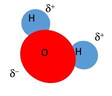

## Water - The Universal Solvent

- Water can dissolve other polar molecules and gases
  - Solids: Salts such as NaCl
  - Liquids: Ethanol (C2H6O)
  - Gases: O2, CO2, CH4
- Water cannot dissolve non-polar molecules
  - Hydrocarbons (motor oils, gasoline, diesel)
  - Glass (SiO2)
  - Plastics (long chains of H, O, and C)

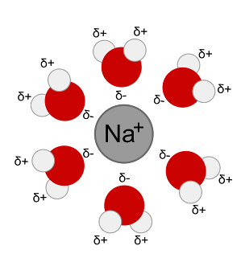

## Concentration

- The mass of a substance (solute) dissolved in either a volume of water (solvent), or dissolved in a mass of water.
- Common concentration units by volume:
  - Parts Per Thousand (ppt) = grams per liter (g/L)
  - Parts Per Million (ppm) = milligrams per liter (mg/L)
  - Parts Per Billion (ppb) = micrograms per L (µg/L)

## Common Nitrogen Species in Solution

- Ammonia: NH3
- Ammonium: NH4+
- **Nitrite: NO2-**
- **Nitrate: NO3-**

## Ways to Report Nitrate Concentrations (units)

- **Nitrate (ppm):** This mass expression states the parts of nitrate present in one million parts of the solution: 2 mg in 1 kg of water would be 2 ppm Nitrate.
- **Nitrate (mg/L):** This value represents the mass of one nitrogen atom PLUS the mass of 3 oxygen atoms (which make up the nitrate molecule) found in one liter of water
- **Nitrate-Nitrogen (NO3-N) (mg/L)**: This term represents the mass of ONLY nitrogen in the nitrate molecules found in one liter of water. Because there is three times more oxygen than nitrogen in nitrate, concentrations of “nitrate” are larger than “nitrate-nitrogen” for the same sample.
  - The U.S. EPA regulations are based on this value.
- **Nitrate+Nitrite Nitrogen (NO3+NO2-N) (mg/L):** This is the mass of nitrogen from both nitrate and nitrite. Nitrite is typically very small in surface water as it rapidly oxidizes to nitrate.
  - USGS reports this value.

## Nutrients vs Toxins

- What are nutrients?
- Where do you find nutrients?
- Are nutrients always “good”?
- Can you ever have too much?
- What are toxins?

## Nutrients

- Nutrients are chemicals that plants and animals need to grow and survive.
- Because water is a universal solvent, all life on Earth utilizes liquid water to obtain and circulate nutrients
  - Young men are 64% water by weight
  - Young women are 53% water by weight
  - The search for extraterrestrial life is focused on finding planets that have liquid water
- For plants:
  - Primary macronutrients include carbon (C), nitrogen (N), phosphorous (P), and potassium (K).
  - Secondary macronutrients include calcium (Ca), magnesium (Mg) and sulfur (S)
  - Micronutrients include copper (Cu), iron (Fe), manganese (Mn), molybdenum (Mo), zinc (Zn) and nickel (Ni), and sometimes boron (B), silicon (Si), cobalt (Co).

## Nutrients vs. Toxins

- Micronutrient: a small amount is needed for biological function
  - Plants: Copper
  - Humans: Cadmium, selenium
- Toxin: a chemical, physical, or biological agent that causes disease or some alteration of the normal structure and function of an organism.
  - Acute toxicity: Immediate impact
  - Chronic toxicity: Impact after a long period of exposure
- When does a nutrient become a toxin?
- A few elements are toxic at all concentrations
  - Mercury, arsenic, lead, thallium
- For most, **concentration dictates toxicity**

## Nitrogen: A Nutrient or Toxin?

- Organisms use nitrogen to produce amino acids, proteins, and nucleic acids.
- 80% of the atmosphere is nitrogen gas (N2)
- Most plants can only take up nitrogen in two forms from soil water, making nitrogen a limiting nutrient in plant growth:
  - Ammonium (NH4+ )
  - Extremely toxic to plants at high concentrations
  - Component of animal waste
  - Nitrate (NO3- )
    - Toxic to humans in drinking water above 10 mg/L NO3-N
    - Blue baby syndrome (NO3 binds to hemoglobin = asphyxiation)

## Impacts of Excess Nitrate

“Nutrient pollution is one of America’s most widespread, costly and challenging environmental problems, and is caused by excess nitrogen and phosphorus in the air and water” (US EPA)

Examples:

- In rivers and lakes, growth of cyanobacteria blooms
- In drinking water resources, blue baby syndrome and cyanotoxins
- In estuaries, hypoxic zones

## Summary of Impacts of Nutrients

- Blooms
  - Ugly and smelly
  - Affect tourism, recreation, and ecosystems
- Drinking water risks
  - Blue Baby Syndrome
  - Cyanotoxins
- Accelerated eutrophication - lakes fill to form wetlands at faster rates
- Hypoxia - Low oxygen leads to fish kills

## Sources of Nutrients: Fertilizer

- Any material of natural or synthetic origin applied to soils or to plant tissues (leaves) to supply one or more plant nutrients essential to the growth of plants.
- More fertilizer addition = Higher crop yield = More money
- No incentive to conserve
- Runoff (Non-point Source) from agricultural fields, lawns, golf courses

## Sources of Nutrients: Waste Water Effluent

- Contains excess C, N, and P not used by animals
- Direct input (Point Source) from wastewater treatment plants and/or septic systems
- Runoff (Non-point Source) from high-density animal feedlots and mega-farms (cows, chickens, other)

## Sources of Nutrients

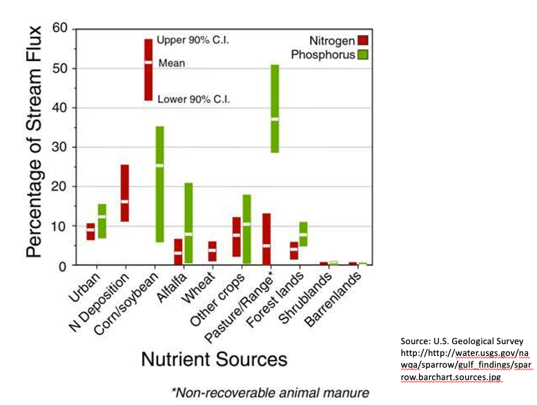

## Sources of Nutrients

[figure not shown]

## The Clean Water Act

The U.S. Clean Water Act (CWA) is a series of federal legislative acts that form the foundation for protection of U.S. water resources:

- Water Quality Act of 1965, Federal Water Pollution Control Act of 1972, Clean Water Act of 1977, and -Water Quality Act of 1987.

The goal of the Clean Water Act (CWA) is “to restore and maintain the chemical, physical, and biological integrity of the Nation’s waters.”

## State 303(d) Lists

- Under section 303(d) of the CWA, states, territories, and authorized tribes, collectively referred to in the act as “states,” are required to develop lists of impaired and threatened waters (stream/river segments, lakes)
- These are waters for which technology-based regulations and other required controls are not stringent enough to meet the water quality standards set by states.
- The law requires that states establish priority rankings for waters on 303(d) lists
- All states submit 303(d) lists for EPA approval every two years on even-numbered years.

## Data Science Skills

- Application Programming Inferences (API)
- Writing functions
- Iteration (loops)

## References

Material derived from:

Devin Castendyk, D. and C. Gibson. April 2016. Project EDDIE: Water Quality. Project EDDIE Module 6, Version 1. http://cemast.illinoisstate.edu/data-for-students/modules/water-quality.shtml Module development was supported by NSF DEB 1245707.